# Intro-to-ChIPseq

## Example5: output a summary of peak consensus

Many methods are available:

1. Use `getAllPeakSequence` module to output fastq file and sesarch the motif by other tools like MEME and HOMER.
2. Compare pre-defined patterns against target consensus patterns with `summarizePatternInPeaks` module.
3. Calculate the z-scores for all combinations of oligonucleotide at a given length with the `oligoSummary` module.

Below demonstrates method 3.

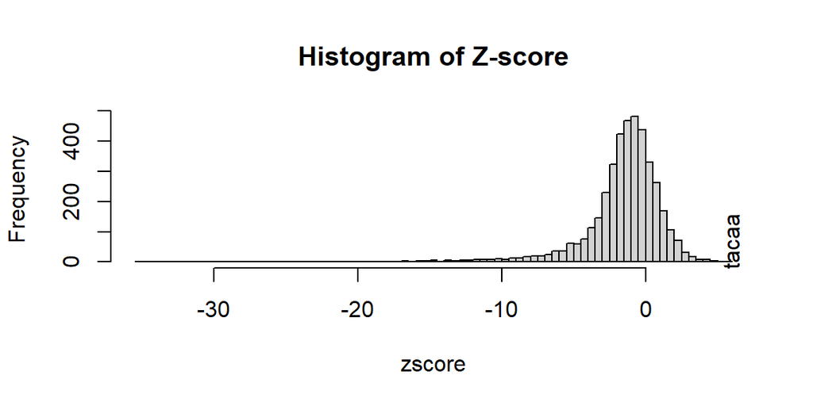

Histogram of Z-score of 6-mer

```r
library(seqinr)
library(BSgenome.Hsapiens.UCSC.hg19)
## obtain peak sequences:
seq <- getAllPeakSequence(overlaps,
                          upstream=20, downstream=20,
                          genome=Hsapiens)
## output the fasta file for the 3nd program:
#write2FASTA(seq, "test.fa")
## summarize short oligos:
os <- oligoSummary(seq, oligoLength=6, MarkovOrder=3, quickMotif=TRUE)
## plot z-scores:
zscore <- sort(os$zscore)
h <- hist(zscore, breaks=100, main="Histogram of Z-score")
text(zscore[length(zscore)], max(h$counts)/10,
     labels=names(zscore[length(zscore)]), srt=90)
```

Generate motif using simulated data.

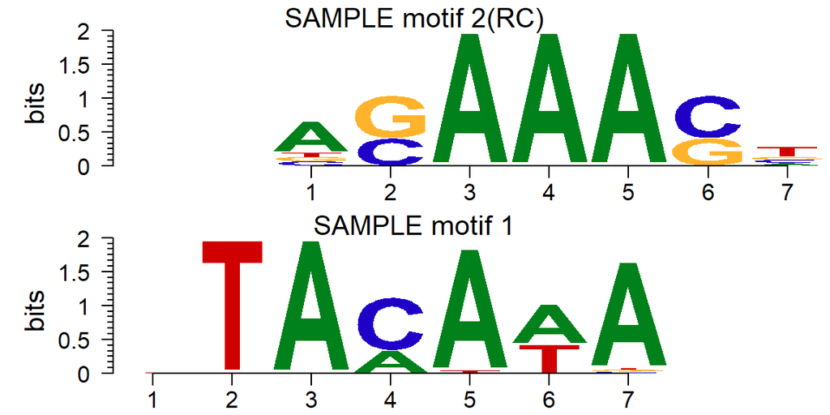

Motif of simulation data

```r
library(motifStack)
## generate the motifs:
pfms <- mapply(function(.ele, id)
               new("pfm", mat=.ele, name=paste("SAMPLE motif", id)),
               os$motifs, 1:length(os$motifs))
motifStack(pfms)
```

## Example6: obtain enriched GO and pathways

```r
library(reactome.db)
## obtain enriched GO term:
over <- getEnrichedGO(overlaps.anno, orgAnn="org.Hs.eg.db",
                      feature_id_type="entrez_id",
                      maxP=.05, minGOterm=10,
                      multiAdjMethod="BH", condense=TRUE)
## show first two lines:
head(over[["mf"]][, -c(3, 10)], n=2)
```

```
## [1] go.id              go.term            Ontology           pvalue
## [5] count.InDataset    count.InGenome     totaltermInDataset totaltermInGenome
## [9] EntrezID
## <0 rows> (or 0-length row.names)
```

```r
## obtain enriched pathways:
pathway <- getEnrichedPATH(overlaps.anno, "org.Hs.eg.db", "reactome.db",
                        feature_id_type="entrez_id", maxP=.05)
## show the first two lines:
head(pathway, n=2)
```

```
##        path.id EntrezID
## 1 R-HSA-196849    65220
## 2 R-HSA-196849    55229
##                                                          path.term
## 1 Homo sapiens: Metabolism of water-soluble vitamins and cofactors
## 2 Homo sapiens: Metabolism of water-soluble vitamins and cofactors
##   count.InDataset count.InGenome     pvalue totaltermInDataset
## 1               2            123 0.03263572                268
## 2               2            123 0.03263572                268
##   totaltermInGenome
## 1            117148
## 2            117148
```

## Example7: determine if there is significant peak overlap among multiple sets

Given multiple peak lists, to see if the binding sites are correlated and what is the common binding pattern. Two methods: hypergeometric test and permutation test.

#### Method 1: hypergeometric test

This method requires the number of all potential binding sites to be known. You need to set the *totalTest* (total potential peak number) in the `makeVennDiagram` module. The value should be larger than the max number of peaks in the peak list.

In the example below, we assume a 3% coding region plus promoters. Since the sample data is only a subset of chr2, we estimate that the total binding sites is 1/24 of possible binding region in the genome.

```r
## read in data: TAF, Tead4 and YY1
path <- system.file("extdata", package="ChIPpeakAnno")
files <- dir(path, "broadPeak")
data <- sapply(file.path(path, files), toGRanges, format="broadPeak")
(names(data) <- gsub(".broadPeak", "", files))
```

```
## [1] "TAF"   "Tead4" "YY1"
```

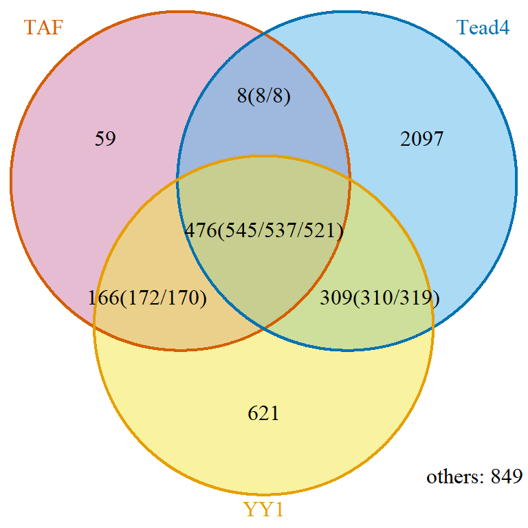

Venn diagram of overlaps.

```
## $p.value
##      TAF Tead4 YY1          pval
## [1,]   0     1   1  1.000000e+00
## [2,]   1     0   1 2.904297e-258
## [3,]   1     1   0  8.970986e-04
##
## $vennCounts
##      TAF Tead4 YY1 Counts count.TAF count.Tead4 count.YY1
## [1,]   0     0   0    849         0           0         0
## [2,]   0     0   1    621         0           0       621
## [3,]   0     1   0   2097         0        2097         0
## [4,]   0     1   1    309         0         310       319
## [5,]   1     0   0     59        59           0         0
## [6,]   1     0   1    166       172           0       170
## [7,]   1     1   0      8         8           8         0
## [8,]   1     1   1    476       545         537       521
## attr(,"class")
## [1] "VennCounts"
```

```r
## find overlapped peaks:
ol <- findOverlapsOfPeaks(data, connectedPeaks="keepAll")
## avergage of peak width:
averagePeakWidth <- mean(width(unlist(GRangesList(ol$peaklist))))
## estimate of total binding site;
tot <- ceiling(3.3e+9 * .03 / averagePeakWidth / 24)
## make Venn diagram:
makeVennDiagram(ol, totalTest=tot, connectedPeaks="keepAll",
                fill=c("#CC79A7", "#56B4E9", "#F0E442"),
                col=c("#D55E00", "#0072B2", "#E69F00"),
                cat.col=c("#D55E00", "#0072B2", "#E69F00"))
```

Keep first list consistent.

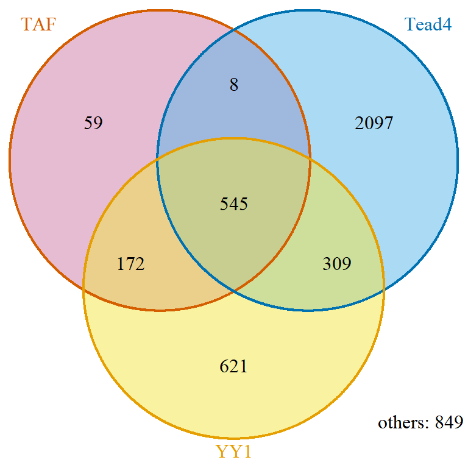

Venn diagram of overlaps for first TF.

```
## $p.value
##      TAF Tead4 YY1          pval
## [1,]   0     1   1  1.000000e+00
## [2,]   1     0   1 2.904297e-258
## [3,]   1     1   0  8.970986e-04
##
## $vennCounts
##      TAF Tead4 YY1 Counts count.TAF count.Tead4 count.YY1
## [1,]   0     0   0    849         0           0         0
## [2,]   0     0   1    621         0           0       621
## [3,]   0     1   0   2097         0        2097         0
## [4,]   0     1   1    309         0         310       319
## [5,]   1     0   0     59        59           0         0
## [6,]   1     0   1    166       172           0       170
## [7,]   1     1   0      8         8           8         0
## [8,]   1     1   1    476       545         537       521
## attr(,"class")
## [1] "VennCounts"
```

```r
## set connectedPeaks to keepFirstListConsistent will show consistent total number of peaks for the first peak list.
makeVennDiagram(ol, totalTest=tot, connectedPeaks="keepFirstListConsistent",
                fill=c("#CC79A7", "#56B4E9", "#F0E442"),
                col=c("#D55E00", "#0072B2", "#E69F00"),
                cat.col=c("#D55E00", "#0072B2", "#E69F00"))
```

#### Method 2: Permutation test

With `peakPermTest`, users don’t need to estimate total potential binding sites.

Before permutation test, random peaks need to be generated using the distribution discovered from the input peak for a given feature type. Alternatively, a peak pool can be prepared with `preparePool` module. Below is an exmple using the transcription factor binding site clusters (V3) (see ?`wgEncodeTfbsV3`) downloaded from [ENCODE](http://hgdownload.cse.ucsc.edu/goldenPath/hg19/encodeDCC/wgEncodeRegTfbsClustered/wgEncodeRegTfbsClusteredV3.bed.gz) with the HOT spots (?`HOT.spots`) removed.

HOT spots are regions with probability to be bound by many TFs. We suggest to remove them before the test. Users can also choose to remove blacklist [ENCODE blacklist](https://sites.google.com/site/anshulkundaje/projects/blacklists) regions. Note that some blacklists need to be converted to the correct genome assembly with liftover utility.

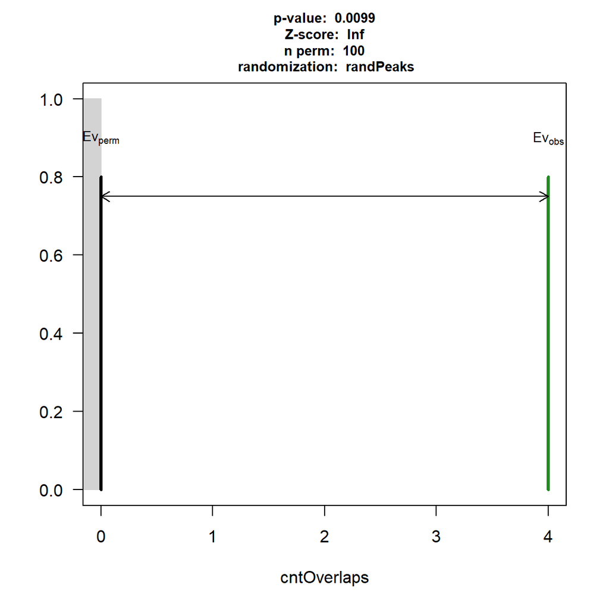

permutation test for YY1 and TEAD4

```r
## read in data:
data(HOT.spots)
data(wgEncodeTfbsV3)
hotGR <- reduce(unlist(HOT.spots))
## remove HOT spots:
removeOl <- function(.ele){
    ol <- findOverlaps(.ele, hotGR)
    if(length(ol)>0) .ele <- .ele[-unique(queryHits(ol))]
    .ele
}
TAF <- removeOl(data[["TAF"]])
TEAD4 <- removeOl(data[["Tead4"]])
YY1 <- removeOl(data[["YY1"]])
## subset to save demo time:
set.seed(1)
wgEncodeTfbsV3.subset <- wgEncodeTfbsV3[sample.int(length(wgEncodeTfbsV3), 2000)]
## YY1 vs TEAD4:
pool <- new("permPool", grs=GRangesList(wgEncodeTfbsV3.subset), N=length(YY1))
pt1 <- peakPermTest(YY1, TEAD4, pool=pool, seed=1, force.parallel=FALSE)
plot(pt1)
```

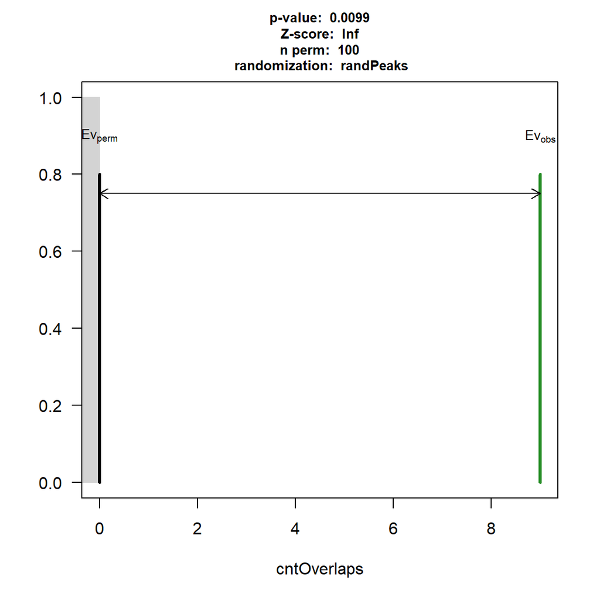

permutation test for YY1 and TAF

```r
## YY1 vs TAF:
pt2 <- peakPermTest(YY1, TAF, pool=pool, seed=1, force.parallel=FALSE)
plot(pt2)
```

## Example8: metagene analysis for a given feature/peak range

You can easily visualize and compare the binding patterns of raw signals of multiple ChIP-seq experiments using function `featureAlignedHeatmap` and `featureAlignedDistribution`.

Heatmap of aligned features.

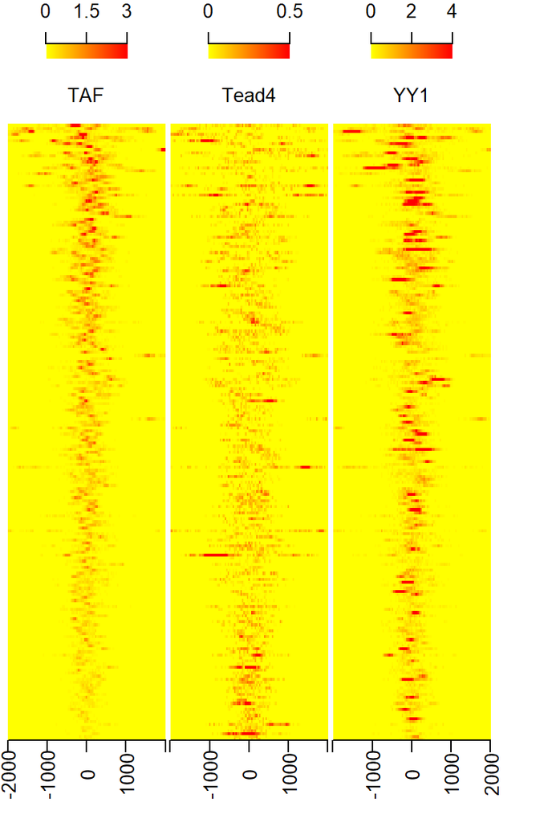

Heatmap of aligned features sorted by signal of TAF

```r
library(rtracklayer)
## recenter features:
features <- ol$peaklist[[length(ol$peaklist)]]
feature.recentered <- reCenterPeaks(features, width=4000)
## read in data:
path <- system.file("extdata", package="ChIPpeakAnno")
files <- dir(path, "bigWig")
if(.Platform$OS.type != "windows"){
    cvglists <- sapply(file.path(path, files), import,
                       format="BigWig",
                       which=feature.recentered,
                       as="RleList")
} else {
    load(file.path(path, "cvglist.rds"))
}
## extract signal:
names(cvglists) <- gsub(".bigWig", "", files)
feature.center <- reCenterPeaks(features, width=1)
sig <- featureAlignedSignal(cvglists, feature.center,
                            upstream=2000, downstream=2000)
## output heatmap
keep <- rowSums(sig[[2]]) > 0
sig <- sapply(sig, function(.ele) .ele[keep, ], simplify = FALSE)
feature.center <- feature.center[keep]
heatmap <- featureAlignedHeatmap(sig, feature.center,
                                 upstream=2000, downstream=2000,
                                 upper.extreme=c(3,.5,4))
```

Distriution of aligned features.

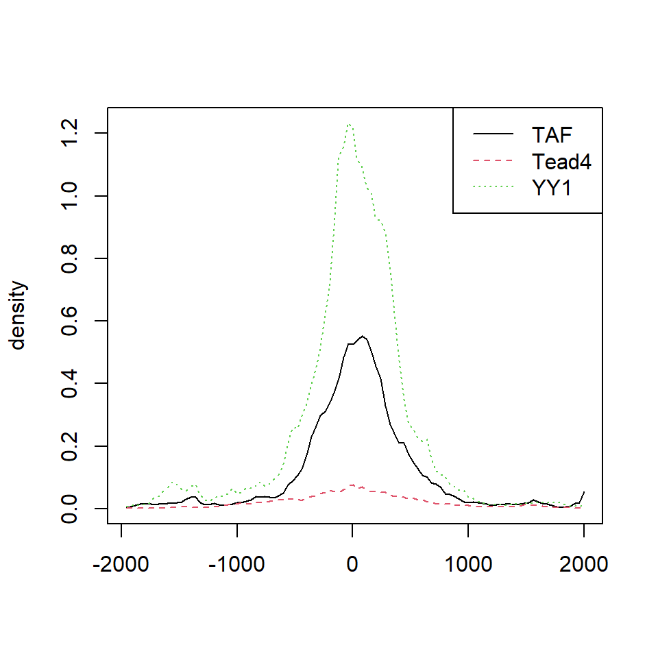

Distribution of aligned features

```r
featureAlignedDistribution(sig, feature.center,
                           upstream=2000, downstream=2000,
                           type="l")
```

## Example9: creating lollipop plot with trackViewer

It is routine to show the distribution of mutation or genetic variations by lollipop-style (or needle-style) plot in a genome browser, along with a variety of genomic annotations, such as gene or exon level models, CpG island, and so on.

For SNP status or methlyation data, lollipop plot is often used. Many tools can provide lollipop plot such as cBioPortal Tools::MutationMapper[@gao2013integrative], EMBL-EBI::Pfam[@finn2006pfam], and BioJS::muts-needle-plot[@michael_p_schroeder_2015_14561], BiQ Analyzer[@bock2005biq], and Methylation plotter[@mallona2014methylation]. The cBioPortal Tools::MutationMapper is a well-known and easy to use online genome browser that can generate high quality figures with mutations by inputing tab-delimited mutation data. In R/Bioconductor, with the Rgraphics system, there are many flexible ways to display methylation data such as *MethVisual*[@zackay2010methvisual], *REDseq*[@zhu4redseq], and *GenVisR*[@skidmore2016genvisr].

Below is a summary of current tools that are available.

| software | inputs | online | description |
| --- | --- | --- | --- |
| MutationMapper[@gao2013integrative] | tab-delimited text | Yes | interprets mutations with different heights along protein annotations in automatic color theme |
| Pfam[@finn2006pfam] | JSON | Yes | could combine different line and head colors with different drawing styles |
| muts-needle-plot[@michael_p_schroeder_2015_14561] | JSON | No | plots data point with different colors, heights, and size along annotations, and highlighted selcted coordinates |
| BiQ Analyzer[@bock2005biq] | BiQ methylation file | Yes | interprets methylation status in black & white |
| Methylation plotter[@mallona2014methylation] | tab-delimited text | Yes | stacked multiple methylation status for multiple samples |
| *MethVisual*[@zackay2010methvisual] | R list | No | visualize the methylation status of CpGs according to their genomic position |
| *REDseq*[@zhu4redseq] | R list | No | plot frequencies of methylations and SNPs along a chromosome |
| *GenVisR*[@skidmore2016genvisr] | R dataframe | No | plot most accurate graphic representation of the ensembl annotation version based on biomart service |

Though the tools above meet the basic even advanced visualization requirement, they do have limitations. For example, it will be hard to display the data if there are multiple mutations in the same posistion. Moreover, generating high quality pictures in bunch for publication is also a pain.

To fill this gap, we developed *trackViewer*, a R/Bioconductor package serving as an enhanced light-weight genome viewer for visualizing various types of high-throughput sequencing data, side by side or stacked with multiple annotation tracks.

Besides the regular read coverage tracks supported by existing genome browsers/viewers, *trackViewer* can also generate lollipop plot to depict the methylation and SNP/mutation status, together with coverage data and annotation tracks to facilitate integrated analysis of multi-omics data. In addition, figures generated by *trackViewer* are interactive, i.e., the feel-and-look such as the layout, the color scheme and the order of tracks can be easily customized by the users. Furthermore, *trackViewer* can be easily integrated into standard analysis pipeline for various high-throughput sequencing dataset such as ChIP-seq, RNA-seq, methylation-seq or DNA-seq. The images produced by *trackViewer* are highly customizable including labels, symbols, colors and size. Here, we illustrate its utilities and capabilities in deriving biological insights from multi-omics dataset from GEO/ENCODE.

There are 3 steps for generating lollipop plot:

1. Prepare the methylation/variant/mutation data.
2. Prepare the gene/protein model.
3. Plot lollipop plot.

#### Step1: repare the methylation/variant/mutation data.

```r
library(trackViewer)
set.seed(123)
# Here we use SNP sample data
SNP <- c(10, 100, 105, 108, 400, 410, 420, 600, 700, 805, 840, 1400, 1402)
# use GenomicRanges::GRanges function to create a GRanges object.
# for real data, users can import vcf data via VariantAnnotation::readVcf function.
sample.gr <- GRanges("chr1", IRanges(SNP, width=1,
                     ## the name of GRanges object will be used as label
                     names=paste0("snp", SNP)),
                     ## score value will be used to for the height of lollipop
                     score = sample.int(5, length(SNP), replace = TRUE),
                     ## set the color for lollipop node.
                     color = sample.int(6, length(SNP), replace = TRUE),
                     ## set the lollipop stem color
                     border = sample(c("black", "gray80", "gray30"),
                     length(SNP), replace=TRUE))
```

#### Step2: prepare the gene/protein model.

```r
features.gr <- GRanges("chr1", IRanges(c(1, 501, 1001),
                                       width=c(120, 400, 405),
                                       names=paste0("exon", 1:3)),
                                                     fill = c("#FF8833", "#51C6E6", "#DFA32D"), ## color for exon
                                                     height = c(0.02, 0.05, 0.08) ## height for exon
                        )
```

#### Step3: plot lollipop plot

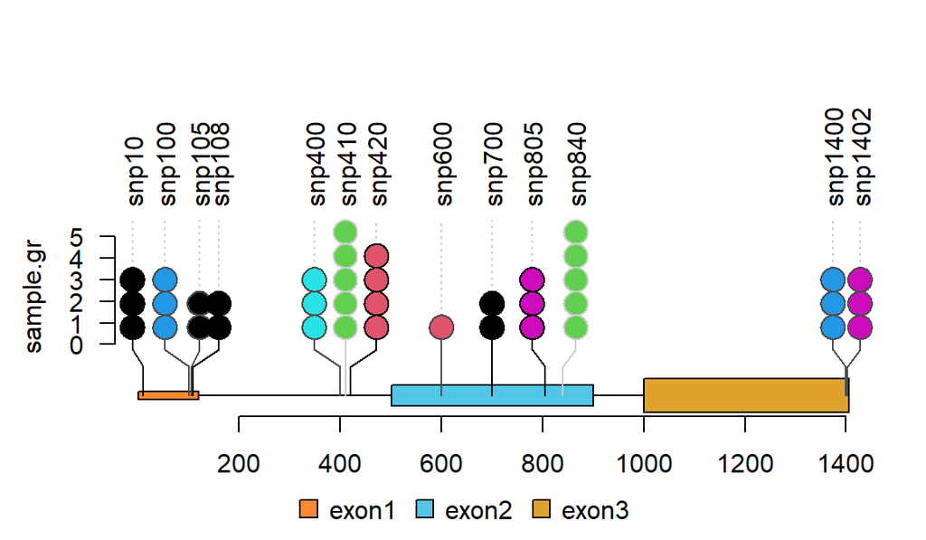

```r
lolliplot(sample.gr, features.gr)
```

## Example10: plot from VCF file with trackViewer

VCF is a text file format that contains metadata and mutation information about genomic positions, original genotypes and optional genotypes.

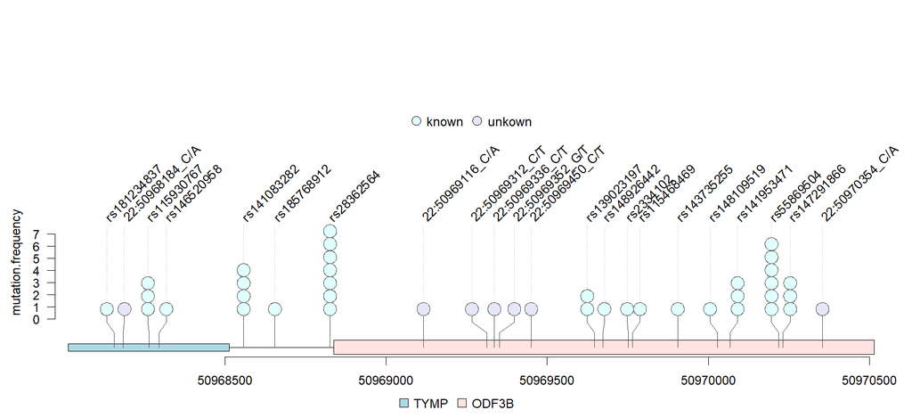

lollipop plot for VCF data

```r
library(VariantAnnotation) ## load package for reading vcf file
library(TxDb.Hsapiens.UCSC.hg19.knownGene) ## load package for gene model
library(org.Hs.eg.db) ## load package for gene name
library(rtracklayer)
fl <- system.file("extdata", "chr22.vcf.gz", package="VariantAnnotation")
## set the track range
gr <- GRanges("22", IRanges(50968014, 50970514, names="TYMP"))
## read in vcf file
tab <- TabixFile(fl)
vcf <- readVcf(fl, "hg19", param=gr)
## get GRanges from VCF object
mutation.frequency <- rowRanges(vcf)
## keep the metadata
mcols(mutation.frequency) <-
    cbind(mcols(mutation.frequency),
          VariantAnnotation::info(vcf))
## set colors
mutation.frequency$border <- "gray30"
mutation.frequency$color <-
    ifelse(grepl("^rs", names(mutation.frequency)),
           "lightcyan", "lavender")
## plot Global Allele Frequency based on AC/AN
mutation.frequency$score <- round(mutation.frequency$AF*100)
## change the SNPs label rotation angle
mutation.frequency$label.parameter.rot <- 45
## keep sequence level style same
seqlevelsStyle(gr) <- seqlevelsStyle(mutation.frequency) <- "UCSC"
seqlevels(mutation.frequency) <- "chr22"
## extract transcripts in the range
trs <- geneModelFromTxdb(TxDb.Hsapiens.UCSC.hg19.knownGene,
                         org.Hs.eg.db, gr=gr)
## subset the features to show the interested transcripts only
features <- c(range(trs[[1]]$dat), range(trs[[5]]$dat))
## define the feature labels
names(features) <- c(trs[[1]]$name, trs[[5]]$name)
## define the feature colors
features$fill <- c("lightblue", "mistyrose")
## define the feature heights
features$height <- c(.02, .04)
## set the legends
legends <- list(labels=c("known", "unkown"),
                fill=c("lightcyan", "lavender"),
                color=c("gray80", "gray80"))
## lollipop plot
lolliplot(mutation.frequency,
          features, ranges=gr, type="circle",
          legend=legends)
```

## Example11: plot methylation data from BED file with trackViewer

Any type of data that can be imported into a `GRanges` object can be viewed by *trackViewer* package.

Sample methylations are random data generated for illustration and are saved in BED format file. The *rtracklayer* package is used to import the methylation data into a `GRanges`. The transcripts are extracted from `TxDb` object and are assigned gene symbol with `org` database. We also demonstrate that multiple transcripts can be shown in different colors and tracks.

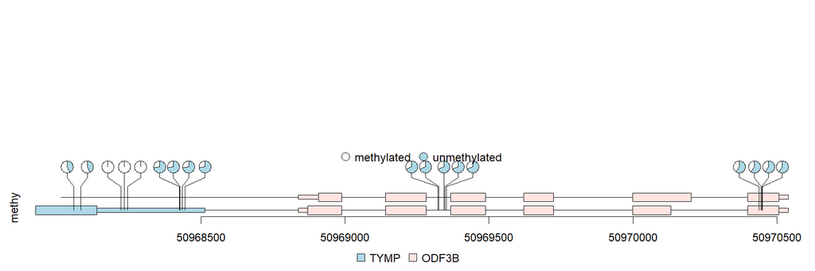

lollipop plot, pie layout

```r
library(TxDb.Hsapiens.UCSC.hg19.knownGene) ## load package for gene model
library(org.Hs.eg.db) ## load package for gene name
library(rtracklayer)
## set the track range
gr <- GRanges("chr22", IRanges(50968014, 50970514, names="TYMP"))
## extract transcripts in the range
trs <- geneModelFromTxdb(TxDb.Hsapiens.UCSC.hg19.knownGene,
                         org.Hs.eg.db, gr=gr)
## subset the features to show the interested transcripts only
features <- GRangesList(trs[[1]]$dat, trs[[5]]$dat, trs[[6]]$dat)
flen <- elementNROWS(features)
features <- unlist(features)
## define the feature track layers
features$featureLayerID <- rep(1:2, c(sum(flen[-3]), flen[3]))
## define the feature labels
names(features) <- features$symbol
## define the feature colors
features$fill <- rep(c("lightblue", "mistyrose", "mistyrose"), flen)
## define the feature heights
features$height <- ifelse(features$feature=="CDS", .04, .02)
## import methylation data from a bed file
methy <- import(system.file("extdata", "methy.bed", package="trackViewer"), "BED")
## subset the data to simplify information
methy <- methy[methy$score > 20]
## for pie plot, there are must be at least two numeric columns
methy$score2 <- max(methy$score) - methy$score
## set the legends
legends <- list(labels=c("methylated", "unmethylated"),
                fill=c("white", "lightblue"),
                color=c("black", "black"))
## lollipop plot, pie layout
lolliplot(methy, features,
          ranges=gr, type="pie",
          legend=legends)
```

## Example12: plot lollipop plot for multiple patients in “pie.stack” layout with trackViewer

The percentage of methylation rates are shown by pie graph in different layers for different patients.

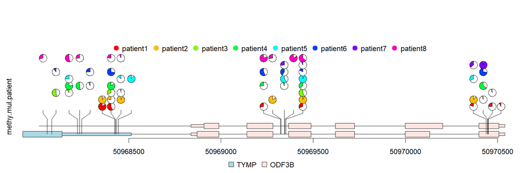

lollipop plot, pie.stack layout

```r
## simulate multiple patients
rand.id <- sample.int(length(methy), 3*length(methy), replace=TRUE)
rand.id <- sort(rand.id)
methy.mul.patient <- methy[rand.id]
## pie.stack require metadata "stack.factor", and the metadata can not be stack.factor.order or stack.factor.first
len.max <- max(table(rand.id))
stack.factors <- paste0("patient",
                        formatC(1:len.max,
                                width=nchar(as.character(len.max)),
                                flag="0"))
methy.mul.patient$stack.factor <-
    unlist(lapply(table(rand.id), sample, x=stack.factors))
methy.mul.patient$score <-
    sample.int(100, length(methy.mul.patient), replace=TRUE)
## for a pie plot, two or more numeric meta-columns are required.
methy.mul.patient$score2 <- 100 - methy.mul.patient$score
## set different color set for different patient
patient.color.set <- as.list(as.data.frame(rbind(rainbow(length(stack.factors)),
                                                 "#FFFFFFFF"),
                                           stringsAsFactors=FALSE))
names(patient.color.set) <- stack.factors
methy.mul.patient$color <-
    patient.color.set[methy.mul.patient$stack.factor]
## set the legends
legends <- list(labels=stack.factors, col="gray80",
                fill=sapply(patient.color.set, `[`, 1))
## lollipop plot
lolliplot(methy.mul.patient,
          features, ranges=gr,
          type="pie.stack",
          legend=legends)
```

## Example13: plot lollipop plot in caterpillar layout to compare two samples with trackViewer

The caterpillar layout can be used to compare two samples or to display dense data side by side.

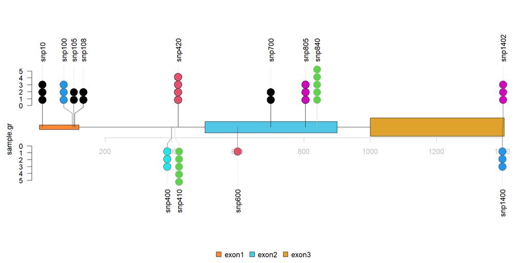

lollipop plot, caterpillar layout

```r
## use SNPsideID to set the layer of event
sample.gr$SNPsideID <- sample(c("top", "bottom"),
                               length(sample.gr),
                               replace=TRUE)
lolliplot(sample.gr, features.gr)
```

## Example14: dandelion plot hundreds SNPs with trackViewer

Sometimes, there are as many as hundreds of SNPs or methylation status involved in one gene. Dandelion plot can be used to depict such dense SNPs or methylation. Please note that the height of the dandelion indicates the density of the events.

```r
methy <- import(system.file("extdata", "methy.bed", package="trackViewer"), "BED")
length(methy)
```

```
## [1] 38
```

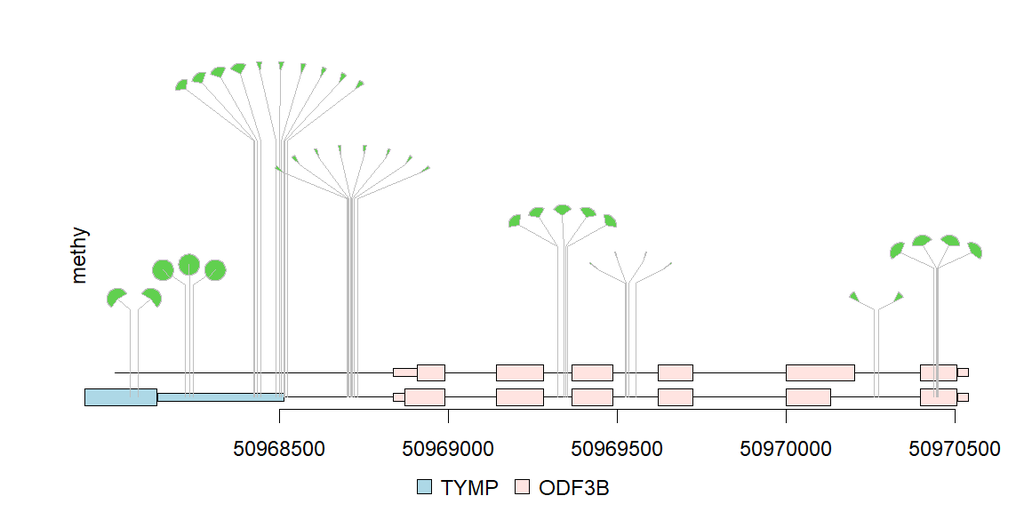

dandelion plot

```r
## set the color of dandelion leaves.
methy$color <- 3
methy$border <- "gray"
## we suppose the total event are same (methy + unmethy)
## we rescale the methylation score by max value of the score
m <- max(methy$score)
methy$score <- methy$score/m
# The area of the fan indicate the percentage of methylation or rate of mutation.
dandelion.plot(methy, features, ranges=gr, type="fan")
```

*This lesson has been developed by members of the teaching team at the [Harvard Chan Bioinformatics Core (HBC)](http://bioinformatics.sph.harvard.edu/). These are open access materials distributed under the terms of the [Creative Commons Attribution license](https://creativecommons.org/licenses/by/4.0/) (CC BY 4.0), which permits unrestricted use, distribution, and reproduction in any medium, provided the original author and source are credited.*